# Dimension Reduction

Viktor Sas

2023-12-17

##Introduction

The goal of my dimension reduction project is to optimize the analysis of diabates dataset collected from the Iraqi society.

The dataset contains essential medical laboratory data such as Blood Sugar Level, Age, Gender, Creatinine ratio (Cr), BMI, Urea, Cholesterol (Chol), Fasting lipid profile, HBA1C, etc.

Dataset with description:

https://data.mendeley.com/datasets/wj9rwkp9c2/1/files/2eb60cac-96b8-46ea-b971-6415e972afc9

First of all, I am loading the data from a csv file called “Dataset of Diabetes.csv”. I am also checking the head of the data, a summary of it and the structure. As we can see, the data needs to be prepared, since the CLASS and Gender attributes are stored as chr.

```r
diabetes <- read.csv('Dataset of Diabetes.csv')
head(diabetes)
```

```
##    ID No_Pation Gender AGE Urea Cr HbA1c Chol  TG HDL LDL VLDL BMI CLASS
## 1 502     17975      F  50  4.7 46   4.9  4.2 0.9 2.4 1.4  0.5  24     N
## 2 735     34221      M  26  4.5 62   4.9  3.7 1.4 1.1 2.1  0.6  23     N
## 3 420     47975      F  50  4.7 46   4.9  4.2 0.9 2.4 1.4  0.5  24     N
## 4 680     87656      F  50  4.7 46   4.9  4.2 0.9 2.4 1.4  0.5  24     N
## 5 504     34223      M  33  7.1 46   4.9  4.9 1.0 0.8 2.0  0.4  21     N
## 6 634     34224      F  45  2.3 24   4.0  2.9 1.0 1.0 1.5  0.4  21     N
```

```r
summary(diabetes)
```

```
##        ID          No_Pation           Gender               AGE
##  Min.   :  1.0   Min.   :     123   Length:1000        Min.   :20.00
##  1st Qu.:125.8   1st Qu.:   24064   Class :character   1st Qu.:51.00
##  Median :300.5   Median :   34396   Mode  :character   Median :55.00
##  Mean   :340.5   Mean   :  270551                      Mean   :53.53
##  3rd Qu.:550.2   3rd Qu.:   45384                      3rd Qu.:59.00
##  Max.   :800.0   Max.   :75435657                      Max.   :79.00
##       Urea              Cr             HbA1c             Chol
##  Min.   : 0.500   Min.   :  6.00   Min.   : 0.900   Min.   : 0.000
##  1st Qu.: 3.700   1st Qu.: 48.00   1st Qu.: 6.500   1st Qu.: 4.000
##  Median : 4.600   Median : 60.00   Median : 8.000   Median : 4.800
##  Mean   : 5.125   Mean   : 68.94   Mean   : 8.281   Mean   : 4.863
##  3rd Qu.: 5.700   3rd Qu.: 73.00   3rd Qu.:10.200   3rd Qu.: 5.600
##  Max.   :38.900   Max.   :800.00   Max.   :16.000   Max.   :10.300
##        TG             HDL             LDL            VLDL
##  Min.   : 0.30   Min.   :0.200   Min.   :0.30   Min.   : 0.100
##  1st Qu.: 1.50   1st Qu.:0.900   1st Qu.:1.80   1st Qu.: 0.700
##  Median : 2.00   Median :1.100   Median :2.50   Median : 0.900
##  Mean   : 2.35   Mean   :1.205   Mean   :2.61   Mean   : 1.855
##  3rd Qu.: 2.90   3rd Qu.:1.300   3rd Qu.:3.30   3rd Qu.: 1.500
##  Max.   :13.80   Max.   :9.900   Max.   :9.90   Max.   :35.000
##       BMI           CLASS
##  Min.   :19.00   Length:1000
##  1st Qu.:26.00   Class :character
##  Median :30.00   Mode  :character
##  Mean   :29.58
##  3rd Qu.:33.00
##  Max.   :47.75
```

```r
str(diabetes)
```

```
## 'data.frame':    1000 obs. of  14 variables:
##  $ ID       : int  502 735 420 680 504 634 721 421 670 759 ...
##  $ No_Pation: int  17975 34221 47975 87656 34223 34224 34225 34227 34229 34230 ...
##  $ Gender   : chr  "F" "M" "F" "F" ...
##  $ AGE      : int  50 26 50 50 33 45 50 48 43 32 ...
##  $ Urea     : num  4.7 4.5 4.7 4.7 7.1 2.3 2 4.7 2.6 3.6 ...
##  $ Cr       : int  46 62 46 46 46 24 50 47 67 28 ...
##  $ HbA1c    : num  4.9 4.9 4.9 4.9 4.9 4 4 4 4 4 ...
##  $ Chol     : num  4.2 3.7 4.2 4.2 4.9 2.9 3.6 2.9 3.8 3.8 ...
##  $ TG       : num  0.9 1.4 0.9 0.9 1 1 1.3 0.8 0.9 2 ...
##  $ HDL      : num  2.4 1.1 2.4 2.4 0.8 1 0.9 0.9 2.4 2.4 ...
##  $ LDL      : num  1.4 2.1 1.4 1.4 2 1.5 2.1 1.6 3.7 3.8 ...
##  $ VLDL     : num  0.5 0.6 0.5 0.5 0.4 0.4 0.6 0.4 1 1 ...
##  $ BMI      : num  24 23 24 24 21 21 24 24 21 24 ...
##  $ CLASS    : chr  "N" "N" "N" "N" ...
```

Next I am cleaning the data, since in the Gender column some of the records were stored as lowercase letters, I make sure that everything is converted into uppercase. In case of CLASS, some of our data contained unnecessary whitespaces.

```r
diabetes <- diabetes %>%
  select(-ID, -No_Pation,)

unique(diabetes$Gender)
```

```
## [1] "F" "M" "f"
```

```r
diabetes$Gender <- toupper(diabetes$Gender)
#convert male to 1 female to 0
diabetes$Gender <- ifelse(diabetes$Gender == 'M', 1, 0)

unique(diabetes$CLASS)
```

```
## [1] "N"  "N " "P"  "Y"  "Y "
```

```r
diabetes$CLASS <- trimws(diabetes$CLASS)
#N = 1, P = 2, Y = 3
diabetes$CLASS <- as.numeric(factor(diabetes$CLASS, levels = c("N", "P", "Y")))

sum(is.na(diabetes))
```

```
## [1] 0
```

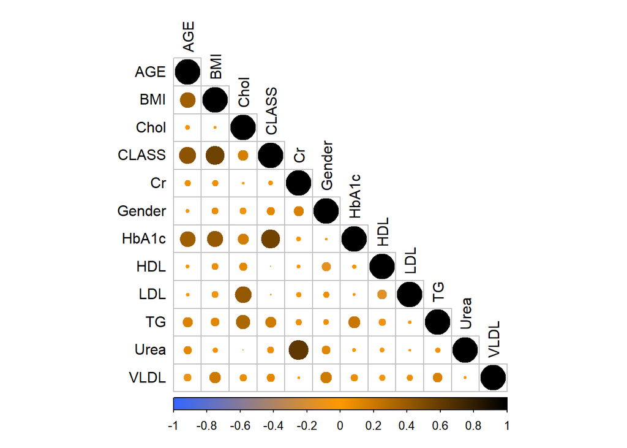

```r
cor.matrix <- cor(diabetes, method = c("pearson"))
corrplot(cor.matrix,
         type = "lower",
         order = "alphabet",
         tl.col = "black",
         tl.cex = 1,
         col = colorRampPalette(c("#3366FF", "#FF9900", "black"))(200))
```

Next, I am using the KMO test and the Bartlett test to see if our data is suitable for factor analysis. Since our overall MSA score is above 0.6, and our p-value = 0, our data is suitable, therefore we can compute PCA (Principal Component Analysis).

```r
KMO(cor.matrix)
```

```
## Kaiser-Meyer-Olkin factor adequacy
## Call: KMO(r = cor.matrix)
## Overall MSA =  0.61
## MSA for each item =
## Gender    AGE   Urea     Cr  HbA1c   Chol     TG    HDL    LDL   VLDL    BMI
##   0.59   0.76   0.52   0.51   0.79   0.45   0.55   0.32   0.40   0.50   0.72
##  CLASS
##   0.71
```

```r
cortest.bartlett(cor.matrix, n=1000)
```

```
## $chisq
## [1] 2289.404
##
## $p.value
## [1] 0
##
## $df
## [1] 66
```

```r
pca <- prcomp(diabetes, center = TRUE, scale = TRUE)

eig.val <- get_eigenvalue(pca)
eig.val
```

```
##        eigenvalue variance.percent cumulative.variance.percent
## Dim.1   2.5605310        21.337759                    21.33776
## Dim.2   1.6912920        14.094100                    35.43186
## Dim.3   1.5131981        12.609984                    48.04184
## Dim.4   1.2450781        10.375651                    58.41749
## Dim.5   1.0427466         8.689555                    67.10705
## Dim.6   0.9310157         7.758464                    74.86551
## Dim.7   0.7704664         6.420554                    81.28607
## Dim.8   0.5918869         4.932391                    86.21846
## Dim.9   0.5137458         4.281215                    90.49967
## Dim.10  0.4407727         3.673105                    94.17278
## Dim.11  0.3539850         2.949875                    97.12265
## Dim.12  0.3452817         2.877347                   100.00000
```

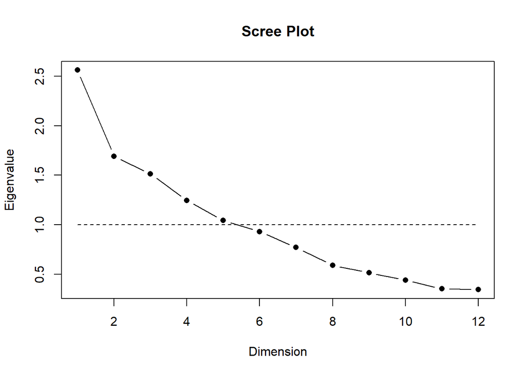

```r
scree.plot(eig.val[,1], title = "Scree Plot", type = "E",  simu = "P")
```

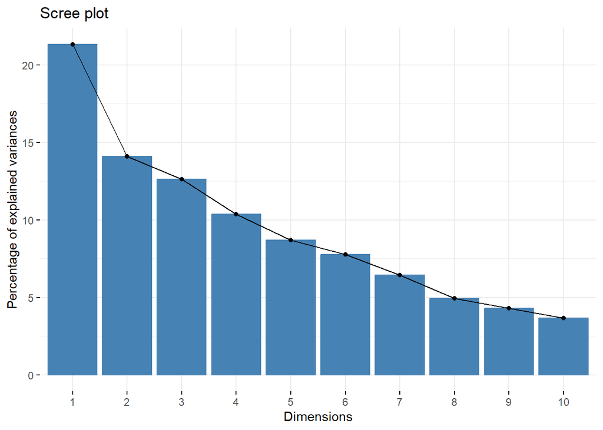

```r
fviz_eig(pca)
```

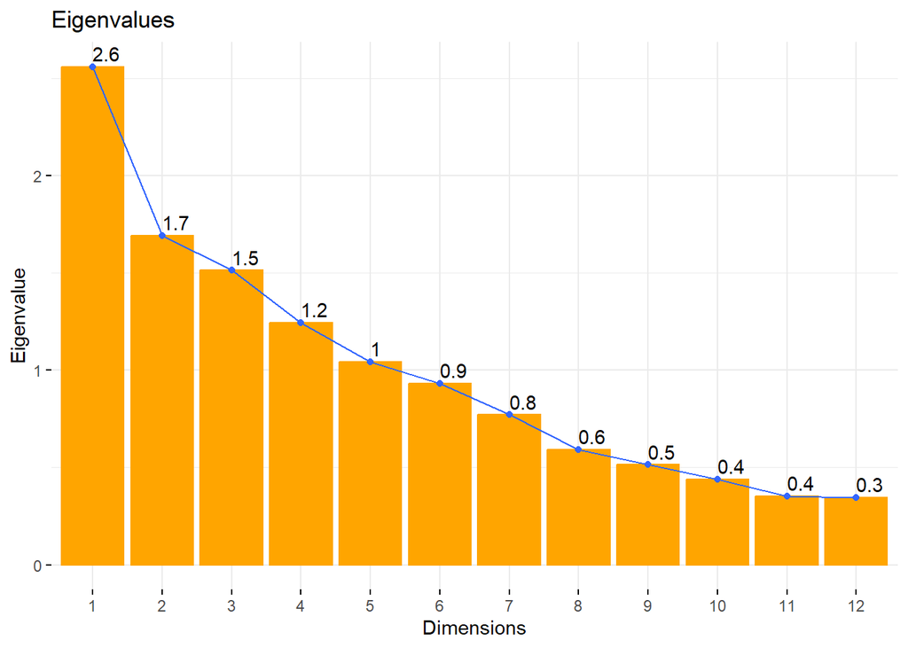

```r
fviz_eig(pca,
         choice = "eigenvalue",
         ncp = 22,
         barfill = 'orange',
         barcolor = "orange",
         linecolor = "#3366FF",
         addlabels = TRUE,
         main = "Eigenvalues")
```

Our correlation circle displays the most important variables, the darker the variable, the more influancial they are.

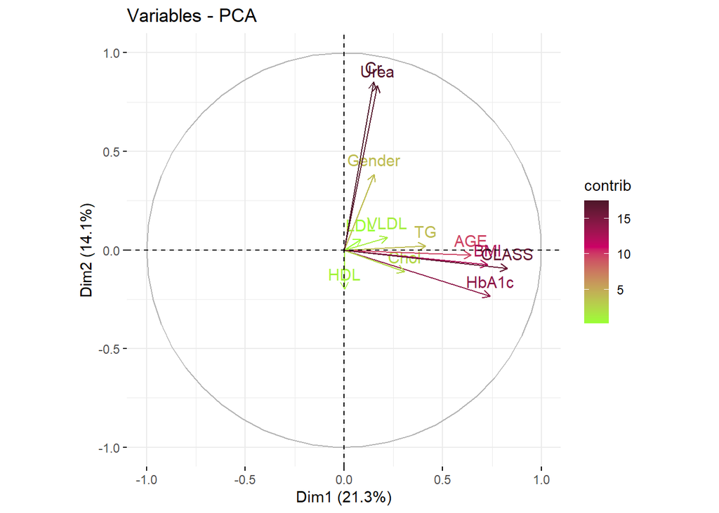

```r
fviz_pca_var(pca, col.var = "contrib")+
  scale_color_gradient2(low="#99FF33", mid="#CC0066",
                        high="black", midpoint=11)
```

The following graph shows the contribution of each variable to our 4 dimensions. The most influancial ones are: Urea, Cr, Chol, CLASS, BMI.

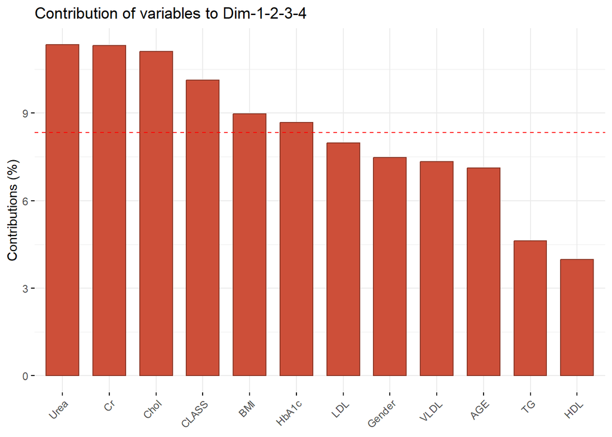

```r
fviz_contrib(pca, "var", axes = 1:4, fill = "tomato3", color = "tomato4")
```

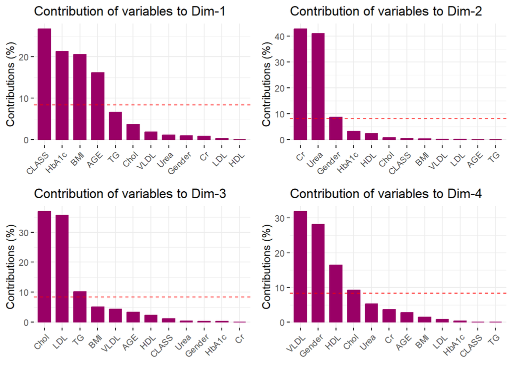

```r
PC1 <- fviz_contrib(pca, choice = "var", axes = 1,fill = "#990066",color = "#990066")
PC2 <- fviz_contrib(pca, choice = "var", axes = 2,fill = "#990066",color = "#990066")
PC3 <- fviz_contrib(pca, choice = "var", axes = 3,fill = "#990066",color = "#990066")
PC4 <- fviz_contrib(pca, choice = "var", axes = 4,fill = "#990066",color = "#990066")


grid.arrange(PC1, PC2, PC3,PC4)
```

The plots above displays which variables contribute the most to each component. In case of component 1 its Class, HbA1c, BMI and Age. 2nd: Cr, Urea, Gender. 3rd: Chol, LDL, TG. 4th: VLDL, Gender, HDL, Chol